# Análise sobre o conjunto de dados do IMDB

Thales Henrique Barros Cardoso

2021-12-27

# Análise dos dados do IMDB

O seu relatório deve (ao menos) responder as seguintes perguntas:

1. Qual o mês do ano com o maior número de filmes? E o dia do ano?
2. Qual o top 5 países com mais filmes na base?
3. Liste todas as moedas que aparecem nas colunas `orcamento` e `receita` da base `imdb_completa`.
4. Considerando apenas orçamentos e receitas em dólar ($), qual o gênero com maior lucro? E com maior nota média?
5. Dentre os filmes na base `imdb_completa`, escolha o seu favorito. Então faça os itens a seguir:
1. Quem dirigiu o filme? Faça uma ficha dessa pessoa: idade (hoje em dia ou data de falecimento), onde nasceu, quantos filmes já dirigiu, qual o lucro médio dos filmes que dirigiu (considerando apenas valores em dólar) e outras informações que achar interessante (base `imdb_pessoas`).
2. Qual a posição desse filme no ranking de notas do IMDB? E no ranking de lucro (considerando apenas valores em dólar)?
3. Em que dia esse filme foi lançado? E dia da semana? Algum outro filme foi lançado no mesmo dia? Quantos anos você tinha nesse dia?
4. Faça um gráfico representando a distribuição da nota atribuída a esse filme por idade (base `imdb_avaliacoes`).

Conforme solicitado, vamos responder as perguntas que foram sugeridas e acrescentar o que acharmos de interessante para a análise dos dados do IMDB.

## 1. Qual o mês do ano com o maior número de filmes? E o dia do ano?

Vamos observar um gráfico treemap com a quantidade de filmes lançados por mês. Dessa forma podemos ver qual o mês tem a maior e menor lançamento de filmes.

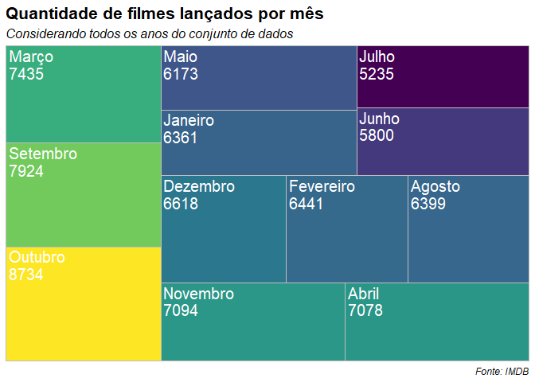

Em seguida temos o dia do mes com mais filmes lançados. Vamos observar o gráfico para ver o comportamento dos lançamentos por dia do mês.

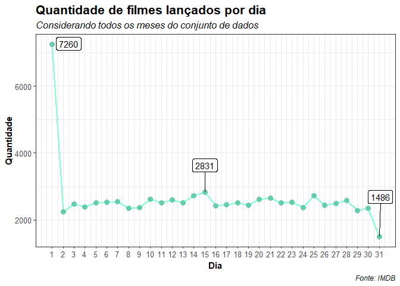

Já que estamos visualizando quantos filmes por mês e por dia foram lançados, vamos aproveitar e verificar qaunto foi o total de lucro agrupando por mês os dados. Para este caso iremos utilizar filtrar apenas os dados onde a moeda da receita e do orçamento são dolares (USD).

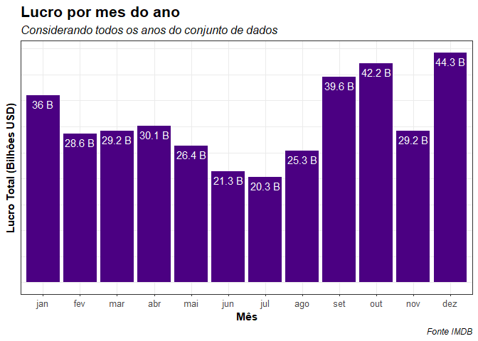

Podemos ver uma nuvens de palavras com os meses que mais e menos lucrativos. Em azul e com o tamanho das letras menor os meses com menores lucros e em vermelho e com a fonte de tamanho maior aqueles que tiveram bons lucros. Sendo uma atividade interessante comparar com o gráfico de barras acima e ver se o tamanho e avcor na nuvem de palavras está condizente com a informação anteriormente mostrada.

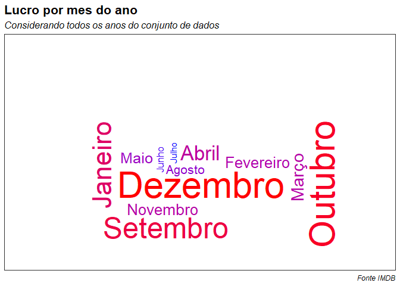

## 2. Qual o top 5 países com mais filmes na base?

Podemos ver através de uma tabela quais são os 5 países com mais filmes no conjunto de dados do IMDB.

| País | Quantidade de Filmes |
| --- | --- |
| United States | 30910 |
| India | 6189 |
| United Kingdom | 5889 |
| France | 5202 |
| Italy | 3785 |

Vamos destacar no mapa mundi os 5 países com mais filmes na base estudada.

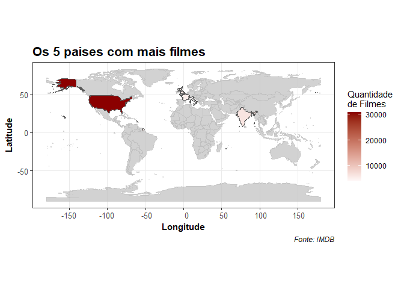

Os países com mais filmes são Estados Unidos, India, Reino Unido, França e Itália. Abaixo, destacaremos no mapa os países europeus que estão no top5 filmes lançados.

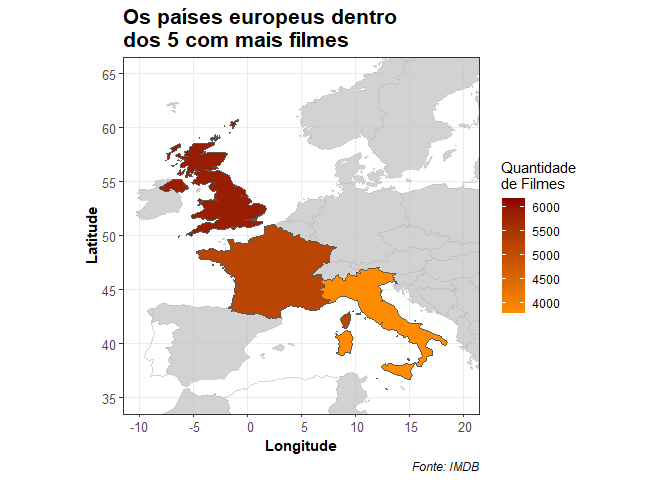

Podemos observar tanto na tabela quanto no mapa que os Estados Unidos possuem uma quantidade de filmes que é desproporcional em relação aos outros países, dessa forma para uma melhor visualização da escala de cores no mapa, vamos visualizar desconsiderando os Estados Unidos.

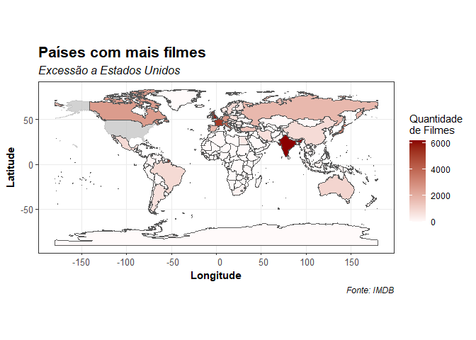

## 3. Liste todas as moedas que aparecem nas colunas `orcamento` e `receita` da base `imdb_completa`.

Como poderemos ver abaixo, o dolar americano domina como sendo a principal moeda dos orçamentos dos filmes contidos na base estudada. Na nuvem de palavras conseguimos observar uma discrepância entro o dolar e outras moedas.

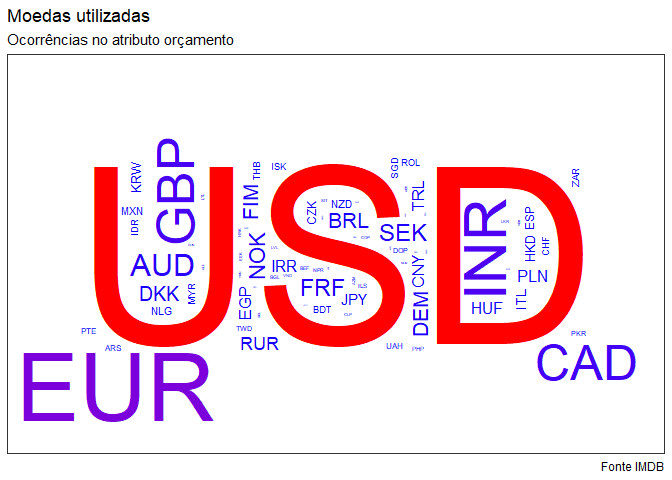

E também como sendo praticamente a moeda majoritária quando se trata de receita dos filmes. Na tabela abaixo podemos ver que o dolar representa 99,80% da receita dos filmes.

| Moeda da Receita | Quantidade de Filmes | Porcentagem do Total (%) |
| --- | --- | --- |
| USD | 30955 | 99.80 |
| INR | 58 | 0.19 |
| GBP | 1 | 0.00 |
| NPR | 1 | 0.00 |
| PKR | 1 | 0.00 |

## 4. Considerando apenas orçamentos e receitas em dólar ($), qual o gênero com maior lucro? E com maior nota média?

Antes de avaliar o gênero com o maior lucro e com a maior nota média, vamos visualizar o comportamento dos gêneros relacionados aos filmes. A coluna gênero possui, em alguns filmes, mais de um gênero relacionado. Dessa forma separamos a coluna em três outras, com os três primeiros gêneros listados. Se algum filme possuir mais do que três gêneros serão considerados para análise até o terceiro listado. Vale a pena ressaltar que estou, também, considerando que o gênero 1 é o principal (primário), o gênero 2 e 3 como apenas complemento, ou seja secundário e terciário. Abaixo nós conseguimos ver como se comporta o fluxo dos gêneros dos filmes de acordo com sua posição, se ele é o principal ou um dos auxiliares.

[interactive chart not shown]

Uma boa coisa a se visualizar é qual o gênero possui mais filmes feitos e depois ver se esse gênero é o que mais lucra.

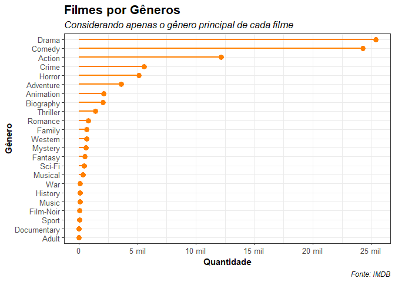

Vamos confirmar através dos números qual gênero possui o maior lucro. Naturalmente o gênero mais produzido tem a tendência de ter uma maior bilheteria acumulada, mas podemos ter casos que não sejam verdade, e somente a base de dados nos dirá com análise. Novamente temos que tomar uma decisão em como utilizar os dados. Para analisar qual o gênero com maior lucro e posteriormente com a maior nota média, vamos utilizar apenas o que consideramos ser como sendo o gênero principal do filme.

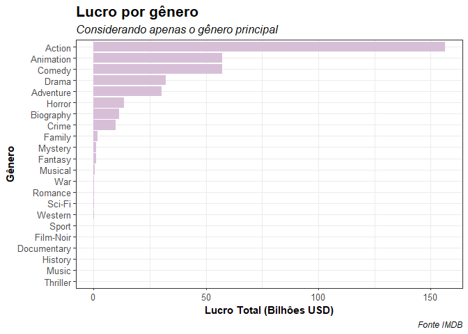

Com essa segunda visualização podemos observar que ter mais filmes feitos em um determinado gênero não é sinônimo de que esse gênero tenha um maior lucro no todo. O gênero drama possui por volta de 26 mil filmes feitos, sendo o gênero com mais observações. Porém o gênero de ação que é o terceiro com mais filmes feitos, fica no topo isolado quando se trata do lucro total. Logo abaixo mostramos a relação entre orçamento, receita e lucro dos filmes com orçamento e receita em dolares. Vamos avaliar se os filmes com maiores orçamentos são os com maiores lucros.

[figure not shown]

## 5. Dentre os filmes na base `imdb_completa`, escolha o seu favorito. Então faça os itens a seguir:

O filme que mais gosto dentro da base do IMDB é *Interstellar*. A partir dessa informação iremos responder as perguntas a seguir.

### a) Quem dirigiu o filme? Faça uma ficha dessa pessoa: idade (hoje em dia ou data de falecimento), onde nasceu, quantos filmes já dirigiu, qual o lucro médio dos filmes que dirigiu (considerando apenas valores em dólar) e outras informações que achar interessante (base `imdb_pessoas`).

Abaixo temo o diretor do filme.

| Diretor |
| --- |
| Christopher Nolan |

Aqui temos a data de nascimento e a sua idade ao dia que o relatório foi gerado.

| Diretor | Data de Nascimento | Data de geração do relatório | Idade |
| --- | --- | --- | --- |
| Christopher Nolan | 1970-07-30 | 2021-12-27 | 51.41 |

Logo em seguida o local de nascimento de Christopher Nolan.

| Cidade | País |
| --- | --- |
| London | England |

Na sequência a quantidade de filmes feitos por Christopher Nolan.

| Diretor | Quantidade de Filmes |
| --- | --- |
| Christopher Nolan | 11 |

No gráfico abaixo será mostrado o lucro por filme, ordenado por ano e com o valor médio do lucro dos filmes de Christopher Nolan.

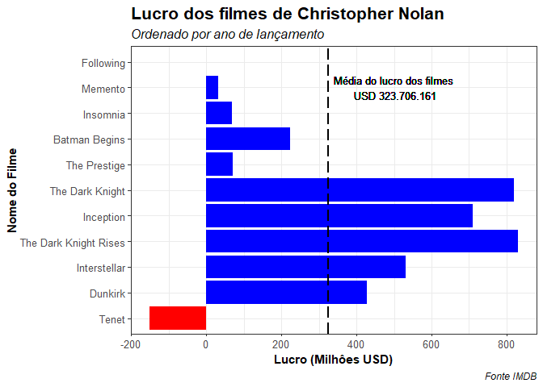

### b) Qual a posição desse filme no ranking de notas do IMDB? E no ranking de lucro (considerando apenas valores em dólar)?

Para responder a posição do filme no ranking de notas do IMDB, vamos considerar a nota média como sendo a referência para essa análise dentro da base `imdb_avaliacoes`. Primeiro devemos saber qual o ID do filme para poder utilizar essa base com as notas.

| Título | id_filme |
| --- | --- |
| Interstellar | tt0816692 |

Podemos observar abaixo que pela nota média o filme Interstellar está na posição 680 no rank.

| Rank Nota | Nota Média |
| --- | --- |
| 680 | 8.6 |

Em relação a posição do filme no rank de maiores lucros obtido na moeda dolar, vemos abaixo que ele ficou na posição 133.

| Rank Lucro | Lucro |
| --- | --- |
| 133 | USD 531.742.056 |

### c) Em que dia esse filme foi lançado? E dia da semana? Algum outro filme foi lançado no mesmo dia? Quantos anos você tinha nesse dia?

Vamo encontrar a data de lançamento e o dia da semana que foi lançado abaixo.

| Filme | Data Lançamento | Dia da Semana |
| --- | --- | --- |
| Interstellar | 2014-11-06 | quinta-feira |

Agora na sequência veremos quais foram os filmes lançados no mesmo dia que Interstellar.

| Filme | Data de Lançamento |
| --- | --- |
| Interstellar | 2014-11-06 |
| The Scribbler | 2014-11-06 |
| Sils Maria | 2014-11-06 |
| Get on Up: La storia di James Brown | 2014-11-06 |
| My Mistress | 2014-11-06 |
| Tre cuori | 2014-11-06 |
| Life Partners | 2014-11-06 |
| Amour fou | 2014-11-06 |
| White Shadow | 2014-11-06 |
| Violet | 2014-11-06 |
| Doraemon - Il film | 2014-11-06 |
| Torneranno i prati | 2014-11-06 |
| Paesyeonwang | 2014-11-06 |
| Pak van mijn hart | 2014-11-06 |
| Is That You? | 2014-11-06 |
| Aanmodderfakker | 2014-11-06 |
| Andiamo a quel paese | 2014-11-06 |
| Vellimoonga | 2014-11-06 |
| Da cha fan | 2014-11-06 |
| Chaar Sahibzaade | 2014-11-06 |
| Varsham | 2014-11-06 |
| Ljubav ili smrt | 2014-11-06 |

Agora veremos a minha idade em anos quando Interstellar foi lançado.

| Filme | Data Lançamento | Meu Nascimento | Minha Idade no Lançamento do Filme |
| --- | --- | --- | --- |
| Interstellar | 2014-11-06 | 1989-04-12 | 25.56879 |

### d) Faça um gráfico representando a distribuição da nota atribuída a esse filme por idade (base `imdb_avaliacoes`).

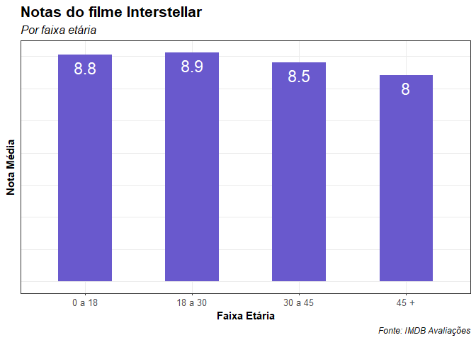

Dessa forma, finalizamos a atividade solicitada, respondendo as perguntas propostas no ínicio do relatório.